# Communicating Datascience Results assignment: Drug markets in San Francisco and Seattle

Paweł Stradowski

22 January 2016

# Introduction

This is an assignment from Coursera course “Communicating Datascience Results” In this analysis, I focus on narcotic sales crimes in Seattle and San Francisco  
Full code of this analysis can be found on Github (git clone https://github.com/pstradowski/SF-SE.git ), feel free to reproduce it, any comments are welcome.

# Preparation

In order to work with the same data, Ineed to filter the crime records, which are related drug sales. For San Francisco, I did this by choosing category DRUG/NARCOTIC which contains word “SALE” in the Descript column

```
##                                       Descript
## 1  POSSESSION OF CONTROLLED SUBSTANCE FOR SALE
## 2      POSSESSION OF METH-AMPHETAMINE FOR SALE
## 3               POSSESSION OF HEROIN FOR SALES
## 4            POSSESSION OF MARIJUANA FOR SALES
## 5                            SALE OF MARIJUANA
## 6     POSSESSION OF BASE/ROCK COCAINE FOR SALE
## 7                    SALE OF BASE/ROCK COCAINE
## 8       POSSESSION OF HALLUCINOGENIC FOR SALES
## 9                               SALE OF HEROIN
## 10                SALE OF CONTROLLED SUBSTANCE
## 11                    SALE OF METH-AMPHETAMINE
## 12             POSSESSION OF COCAINE FOR SALES
## 13         POSSESSION OF AMPHETAMINE FOR SALES
## 14                             SALE OF OPIATES
## 15           POSSESSION OF METHADONE FOR SALES
## 16                             SALE OF COCAINE
## 17             POSSESSION OF OPIATES FOR SALES
## 18                         SALE OF BARBITUATES
```

In case of Seattle, I choose records, which contain “NARC-SELL” in the *Offense.Type* field, here comes the list:

```
##            Offense.Type
## 1      NARC-SELL-HEROIN
## 2     NARC-SELL-COCAINE
## 3        NARC-SELL-METH
## 4 NARC-SELL-AMPHETAMINE
## 5   NARC-SELL-SYNTHETIC
## 6      NARC-SELL-MARIJU
```

# Visualisations

As first step, I suggest to use interactive maps of both cities with markers set in each place, where a criminal event occured. Browsing the maps with appropriate zoom gives an insight into spatial distribution of narcotics crimes in both cities.  
Seattle

[interactive chart not shown]

San Francisco

[interactive chart not shown]

Above maps present the individual crime incidents, but in order to have better view, one can use density estimation to find potential centers. Seattle has two drug sales centers in the downtown located not far away from each other

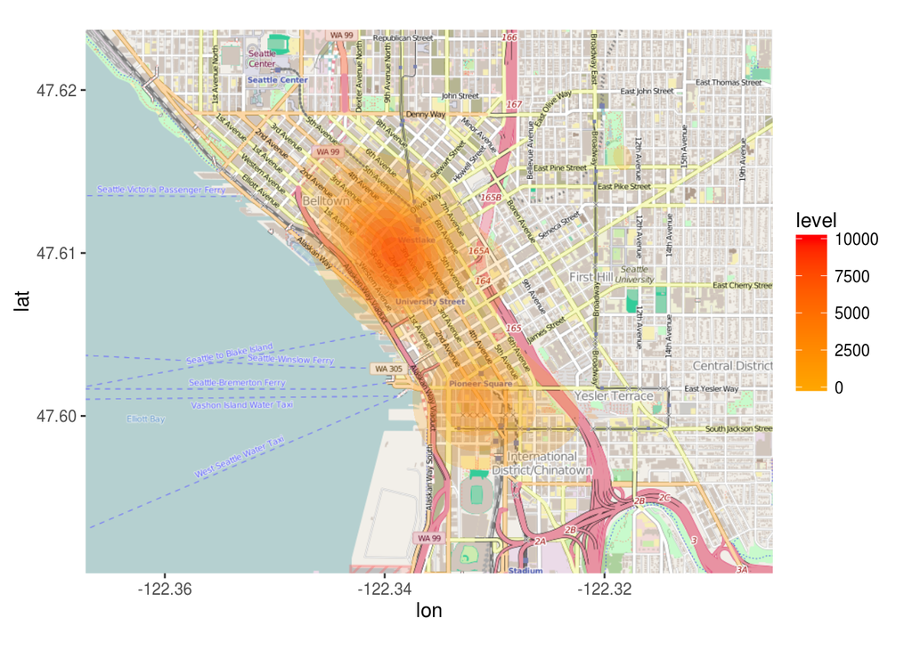

San Francisco is different - there are 3 centers, but one of them strongly dominates the rest. It could be related to the city organisation - the center is located in quarter full of bars and restaurants - place where people entertain is nattural target for drug dealers and depending on the city organisation, there could be more than one such quarter.

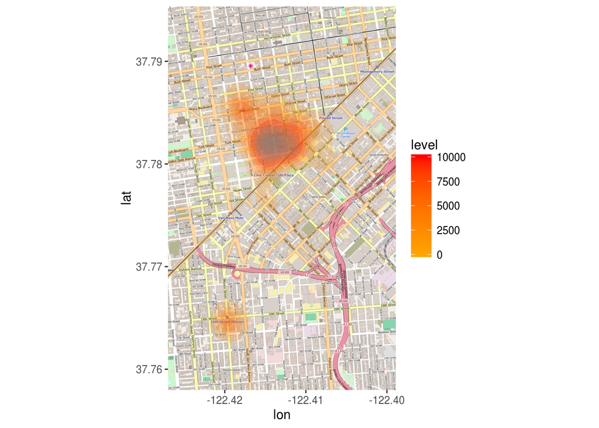

One could notice that on above maps, the density of crimes is higher in San Francisco, it is related to pupulation density - in case of San Francisco, it is very big.  
It would be also interesting to have a look at narco crime incidents per capita.

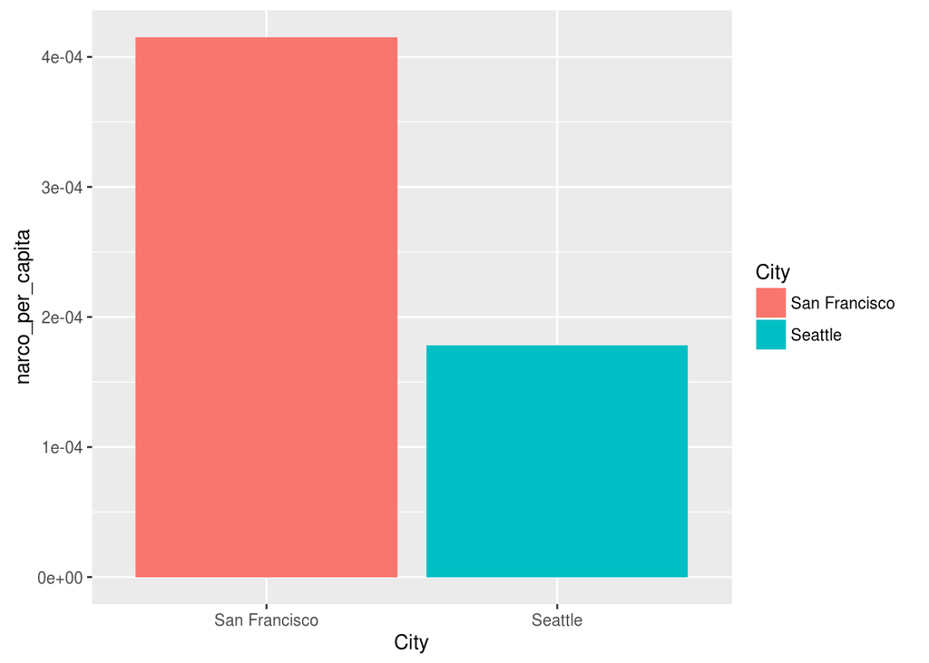

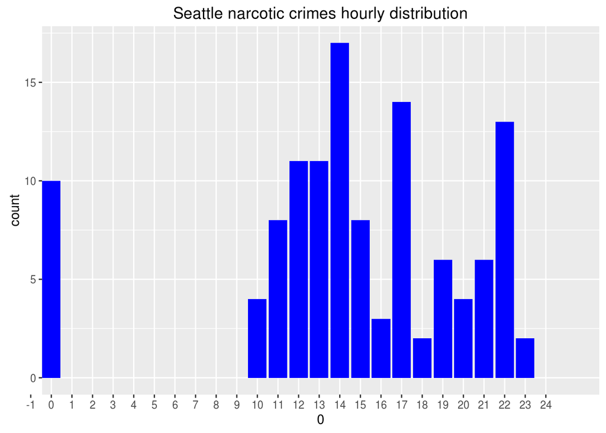

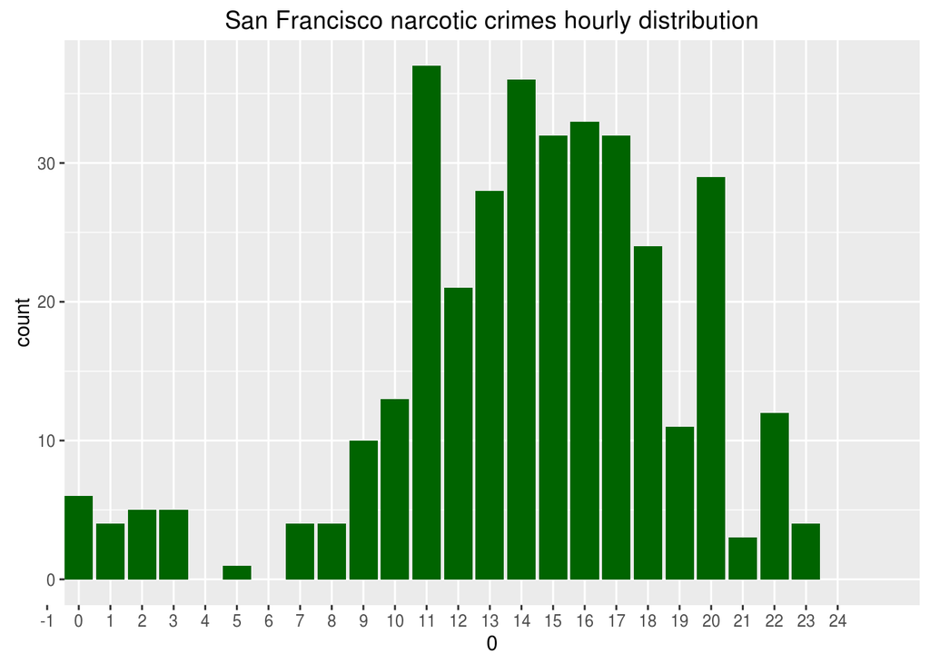